# Lab 3

# Problem 1

```python
%matplotlib inline
import numpy as np
import matplotlib
import matplotlib.pyplot as plt
import scipy
from scipy import stats

#this sets the size of the plot to something useful
plt.rcParams["figure.figsize"] = (20,15)
```

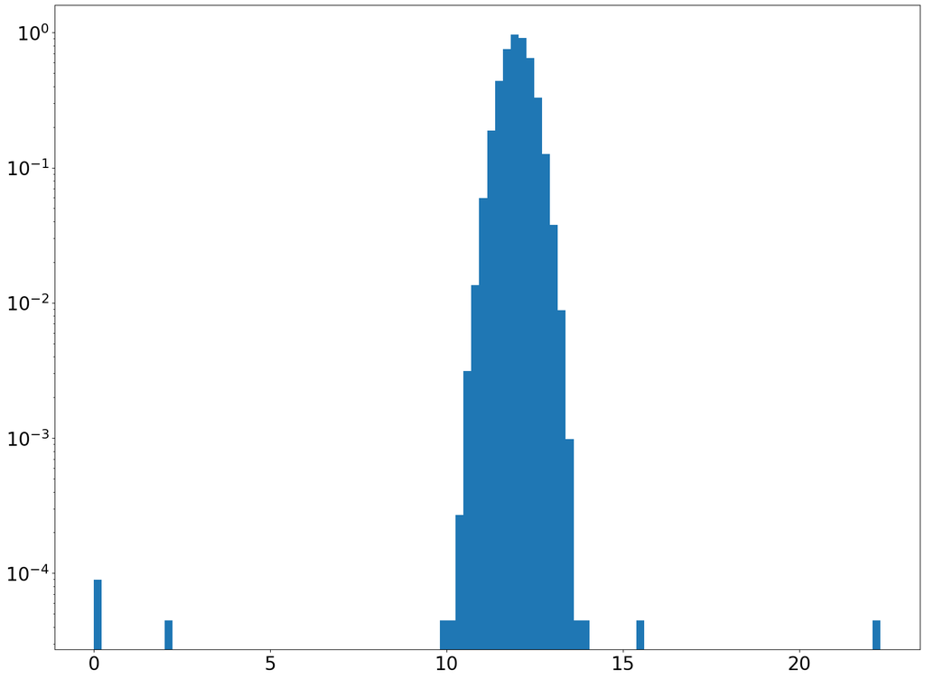

```python
d = np.append(stats.norm.rvs(loc = 12., scale = 0.4, size = 100000), [10., 10.3, 2.1, 0., 0., 15.6, 22.3, 12.7])
fig, ax = plt.subplots(1, 1)
ax.hist(d,100, density=True)
plt.tick_params(labelsize = 24)
plt.yscale('log')
#x = np.linspace(4.95,5.05,1000)
#ax.plot(x,stats.norm.pdf(x,loc = 5., scale = 0.01),linewidth = 8,alpha = 0.7)
plt.show()
```

**A) So our goal is to identify bad data and throw it out.**

1. Start by exploring the data you have created with appropriate plots

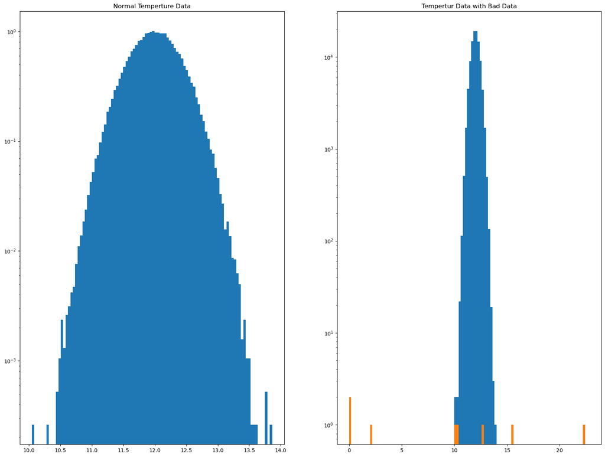

```python
fig, (ax_1, ax_2) = plt.subplots(1, 2)

good = stats.norm.rvs(loc = 12., scale = 0.4, size = 100000)
bad = [10., 10.3, 2.1, 0., 0., 15.6, 22.3, 12.7]
ax_1.hist(good, 100, density = True)
ax_1.set_yscale('log')
ax_1.title.set_text('Normal Temperture Data')

good = np.append(good, bad)
ax_2.hist(good, np.arange(0, 23, 0.2))# array bad's min is 0, max is 22.3
ax_2.hist(bad, np.arange(0, 23, 0.2))
ax_2.set_yscale('log')
ax_2.title.set_text('Tempertur Data with Bad Data')
plt.show()
```

1. State the statistical question in words. Be very clear, and describe why you have chosen this statistical question. Restate your question in math. Be very clear.

Suppose there's a temperature measurement X. What is the probability that a measurement at 12 Kelvin within the SD 0.4, would be far away from mean than X? Suppose measurement cannot exceeds 3 $\sigma$.

1. Restate your question in math. Be very clear.

probability of X from gaussian distribution with 12Kelvin within SD 0.4: $$P(X) = 2 \int_{|X-12|}^\infty\frac{1}{0.4}e^{\frac{-1}{2} (\frac{x}{0.4})^2}$$

Then we use quantile function: $$Q(p) = (2p-1) \sqrt{\frac{1}{2p-2p^2}}$$

Finally, if the answear is bigger than 3, we discard the answear.

1. Apply your statistical test and construct a truth table.

```python
dist = abs(stats.norm.rvs(loc = 12., scale = 0.4, size = 100000) - 12)
bad = abs(np.array(bad) - 12)
good_kept = 0
good_throw = 0
bad_kept = 0
bad_throw = 0

p1 = 1 - stats.norm.cdf(-dist, scale = 0.4)
ppf1 = stats.norm.ppf(p1, loc = 0, scale = 1)
p2 = 1 - stats.norm.cdf(-bad, scale = 0.4)
ppf2 = stats.norm.ppf(p2,loc = 0, scale = 1)

# go through each ppf.
for x1 in ppf1:
    if x1 <= 3:
        good_kept +=1
    else:
        good_throw +=1


for x2 in ppf2:
    if x2 <= 3:
        bad_kept +=1
    else:
        bad_throw +=1

print("Good kept: ", good_kept, "\nGood throw: ", good_throw)
print("Bad kept: ", bad_kept, "\nBad throw: ", bad_throw)
```

```
Good kept:  99732
Good throw:  268
Bad kept:  2
Bad throw:  6
```

|  | Good | Bad |  |  |
| --- | --- | --- | --- | --- |
| Kept | 99732 | 2 |  |  |
| Throw | 268 | 6 |  |  |

**B) How does the number of omissions, where you threw out good data, depend on the statistical threshold you chose and is it a predictable quantity?**

```python
#reset the count
good_kept = 0
good_throw = 0
bad_kept = 0
bad_throw = 0

# lower the threshold to 1 sigma
for x1 in ppf1:
    if x1 <= 1:
        good_kept +=1
    else:
        good_throw +=1


for x2 in ppf2:
    if x2 <= 1:
        bad_kept +=1
    else:
        bad_throw +=1

print("Good kept: ", good_kept, "\nGood throw: ", good_throw)
print("Bad kept: ", bad_kept, "\nBad throw: ", bad_throw)
```

```
Good kept:  68153
Good throw:  31847
Bad kept:  2
Bad throw:  6
```

|  | Good | Bad |  |  |
| --- | --- | --- | --- | --- |
| Kept | 68153 | 2 |  |  |
| Throw | 31847 | 6 |  |  |

```python
#reset the count
good_kept = 0
good_throw = 0
bad_kept = 0
bad_throw = 0

# lower the threshold to 2 sigma
for x1 in ppf1:
    if x1 <= 2:
        good_kept +=1
    else:
        good_throw +=1


for x2 in ppf2:
    if x2 <= 2:
        bad_kept +=1
    else:
        bad_throw +=1

print("Good kept: ", good_kept, "\nGood throw: ", good_throw)
print("Bad kept: ", bad_kept, "\nBad throw: ", bad_throw)
```

```
Good kept:  95285
Good throw:  4715
Bad kept:  2
Bad throw:  6
```

|  | Good | Bad |  |  |
| --- | --- | --- | --- | --- |
| Kept | 95285 | 2 |  |  |
| Throw | 4715 | 6 |  |  |

```python
#reset the count
good_kept = 0
good_throw = 0
bad_kept = 0
bad_throw = 0

# lower the threshold to 5 sigma
for x1 in ppf1:
    if x1 <= 5:
        good_kept +=1
    else:
        good_throw +=1


for x2 in ppf2:
    if x2 <= 5:
        bad_kept +=1
    else:
        bad_throw +=1

print("Good kept: ", good_kept, "\nGood throw: ", good_throw)
print("Bad kept: ", bad_kept, "\nBad throw: ", bad_throw)
```

```
Good kept:  100000
Good throw:  0
Bad kept:  3
Bad throw:  5
```

|  | Good | Bad |  |  |
| --- | --- | --- | --- | --- |
| Kept | 100000 | 3 |  |  |
| Throw | 0 | 5 |  |  |

**C) Are there mistakes of commission (bad data getting in)? If yes, are they avoidable and how do they depend on your statistical threshold?**

Yes, there can be mistakes of commission. for $5\sigma$, we still have few bad data point and statistically speaking, they are avoidable if we set the statistical threshold with smaller value. However, if we set the threshold too small we will omit more good data, so compare to the losing of good data, the small mistakes is nothing to worry,

## Problem 2

In this example we will be looking for asteroids. If we look at the alignment of stars on subsequent images, they don't perfectly align due to atmospheric and instrumental effects (even ignoring proper motion). The resulting distribution is two dimensional, and for this lab let's assume it is a 2D Gaussian with 1 arcsecond RMS. Or said another way, if I histogram how far all the (stationary) stars appear to have moved I get something like:

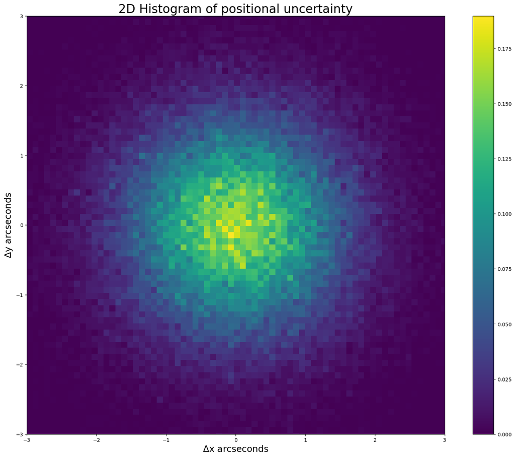

```python
a = np.vstack((stats.norm.rvs( scale = 1, size = 100000), stats.norm.rvs( scale = 1, size = 100000)))
a.shape
fig, ax = plt.subplots(1, 1)
h = ax.hist2d(a[0,:],a[1,:],bins=100, density=True);
ax.set_aspect('equal', 'box')
plt.xlim([-3 , 3])
plt.ylim([-3 , 3])
plt.title("2D Histogram of positional uncertainty", fontsize = 24)
plt.ylabel("$\Delta$y arcseconds", fontsize = 18)
plt.xlabel("$\Delta$x arcseconds", fontsize = 18)
plt.colorbar(h[3], ax=ax)
```

**We would like a '5 sigma' detection of movement. What is that distance in arcseconds?**

What is the radius around the center of the image that detections outside of that radius have more than or equal to $5\sigma$?

We knoe that the magnitude of a vector of two independent Gaussians is a Rayleigh distribution, the pdf of this Rayleigh distribution is: $p(x)=\frac{x}{\sigma^2}e^{\frac{-x^2}{2\sigma^2}}$

Gaussian distributions with $\sigma = 1$, we got the cdf: $ C(r) = 1-e^{\frac{-a^2}{2}}$ and Quantile function is: $Q=\sqrt{-2\ln(1-C(r))}$

If the answear of Q is larger than 5, then it's discard.

```python
# A while loop to increase the distance until we reach 5 sigma.
d = 0
sigma = 0
n = 0

while n < 4:
    p = stats.rayleigh.cdf(d)
    sigma = stats.norm.ppf(p)
    if(sigma < 5):
        d = d + 0.1**n
    else:
        d = d - 0.1**n
        n += 1
n -= 1
d = d + 0.1**n
sigma
```

```
5.000973902119513
```

```python
d
```

```
5.49
```

The distance is about 5.49 arcseconds for $5\sigma$

## Problem 3

Assume in a moon sized patch on the sky we normally have a cosmic ray rate of 1 cosmic ray per minute (arrivals are random in time). If we can observe where the moon is for 8 hours per night (not too close to the horizon) and we observe for 15 days and see 6800 cosmic rays, what is the signficance of our moon shadow detection?

Assume a poisson signal free background pdf with mu qeual to 1 cosmic ray/min, what is the significane of detecting 6800 gamma rays after 7200minutes?

$\lambda = 7200$ and $k = 6800$

We integrate pmf of our background from 0 to 6800 then convert it to sigma. The precise formula for integrattion: $P(k |\lambda) = e^{-\lambda} \sum \limits_{i=0}^k \frac{\lambda^i}{i!}$

```python
dist = stats.poisson(7200)
p = dist.cdf(6800)
p
```

```
1.0133280183917768e-06
```

```python
stats.norm.ppf(p)
```

```
-4.750747965777188
```

So the significance is $ 4.75\sigma$